# Imputation of Missing Values in the Melbourne CBD Pedestrian Dataset

## Public Holiday Code

```r
## read data from data.gov.au
pub_hday14 <- read.csv("http://data.gov.au/dataset/b1bc6077-dadd-4f61-9f8c-002ab2cdff10/resource/56a5ee91-8e94-416e-81f7-3fe626958f7e/download/australianpublicholidays-201415.csv---australianpublicholidays.csv.csv")
pub_hday15 <- read.csv("http://data.gov.au/dataset/b1bc6077-dadd-4f61-9f8c-002ab2cdff10/resource/13ca6df3-f6c9-42a1-bb20-6e2c12fe9d94/download/australianpublicholidays-201516.csv")
pub_hday16 <- read.csv("http://data.gov.au/dataset/b1bc6077-dadd-4f61-9f8c-002ab2cdff10/resource/a24ecaf2-044a-4e66-989c-eacc81ded62f/download/australianpublicholidays-201617.csv")
pub_hdays <- rbind(pub_hday14, pub_hday15, pub_hday16)

pub_hdays$Date <- ymd(pub_hdays$Date)
pub_hdays$Month <- pub_hdays$Date %>% month(label = TRUE, abbr = FALSE)
pub_hdays$VIC <- 0
pub_hdays$VIC[grep(glob2rx("*VIC*"), pub_hdays$`Applicable To`)] <- 1
pub_hdays$VIC[grep("NAT", pub_hdays$`Applicable To`)] <- 1

dates1 <- full_seq(ped_data$Date_Time, period = 3600)
hdayvals <- rep(0, length(dates1))
hdayvals[as.Date(dates1) %in% pub_hdays$Date[pub_hdays$VIC == 1]] <- 1
dates2 <- as.Date(rep(dates1, each = 43))
hdayvals2 <- as.numeric(rep(hdayvals, each = 43))

ped_data$IsHDay <- hdayvals2
ped_data$HDay <- ped_data$Day
levels(ped_data$HDay) <- c(levels(ped_data$Day), "Holiday")
ped_data$HDay[ped_data$IsHDay == 1] <- "Holiday"
```

This code uses official public holiday data from `data.gov.au` to check if dates fall on public holidays. The code ensures only public holidays which apply to Victoria are used.

## Code for Day Type

Compacts the `HDay` factor into 6 levels, rather than 8 levels, by coding Tuesday, Wednesday and Thursday as factor `"Midweek"`. This is because at most locations, these days have similar patterns. For instance, we see this at Melbourne Central:

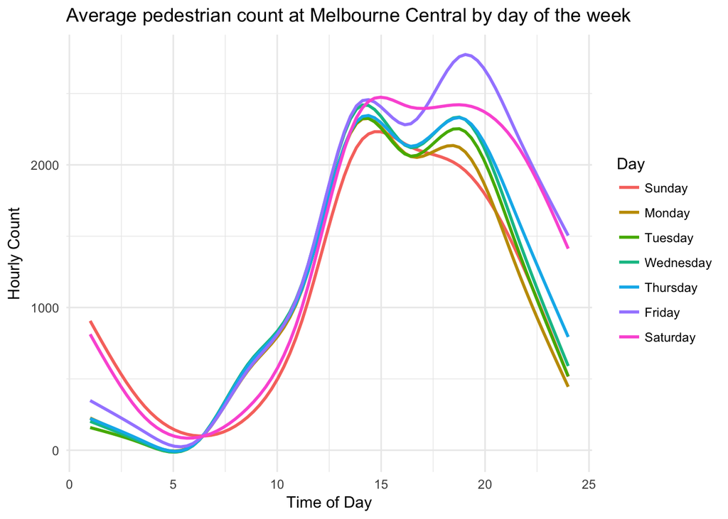

## GLM model for imputing missings

```r
ped_list <- ped_data %>% filter(Date < "2017-01-01") %>%
            split(.$Sensor_ID)

ped_coeffs <- list()
ped_model_fitted <- list()
ped_model_summary <- list()
p <- progress_estimated(43)
options(na.action = 'na.omit')
for (i in 1:43) {
  p$tick()$print()
  train <- ped_list[[i]]
  ped_model_i <- glm(Hourly_Counts ~ Month + DayType*Time,
                     family = quasipoisson(), data = train)
  ped_coeffs[[i]] <- ped_model_i$coefficients
  ped_model_summary[[i]] <- summary(ped_model_i)
}
rm(ped_model_i)
```

The code above fits a GLM model for each sensor location. This model uses a quasi-poisson distribution to allow of overdispersion. Using a standard poisson distribution would give the restriction of mean = variance.  
The model is specified as `Hourly_Counts ~ Month + DayType * Time`, where `Month` is given an additive effect, and `DayType * Time` gives an interaction term between `DayType` and `Time`, as well as any other indirect additive effects. To improve efficiency, only the coefficients of the model are retained, as well as model summarries for model evaluation.  
We train the model only on the data from 2014 to 2016. The test data set is the data available from 2017.

### Test data fit

```r
test_ped <- ped_data %>% filter(Date > "2016-12-31") %>%
            split(.$Sensor_ID)
## required for model.matrix to allow NAs
options(na.action = 'na.pass')

for (i in 1:43) {
  test_df <- model.matrix(Hourly_Counts ~ Month + DayType*Time,
                          data = test_ped[[i]])
  test_coeff <- ped_coeffs[[i]]
  if (length(test_coeff) < ncol(test_df)) {
    missing_cols <- setdiff(colnames(test_df), rownames(as.data.frame(test_coeff)))
    test_df <- test_df[, !(colnames(test_df) %in% missing_cols)]
  }

  test_preds <- exp(test_df %*% test_coeff)
  test_ped[[i]]$Fitted <- test_preds
}

test_fitted <- bind_rows(test_ped)
```

Using the coefficients saved for each location, we can easily fit the test data.  
With the function `model.matrix()`, `R` will generate a matrix, $X_j = \{ X_{1j}, X_{2j}, \dots , X_{Tj} \}$, with the factor levels converted into dummy variables for use with the GLM. Then, we can obtain our estimates of $\text{Hourly_Counts}_{j}$, $\widehat{\text{Hourly} \_ \text{Counts}}_{j} = \exp \left( X_j\hat{\beta_j} \right)$ where $\hat{\beta_j}$ is a column vector of the GLM estimated coefficients at the $j^{th}$ sensor location.

# Goodness of Fit

### Visually

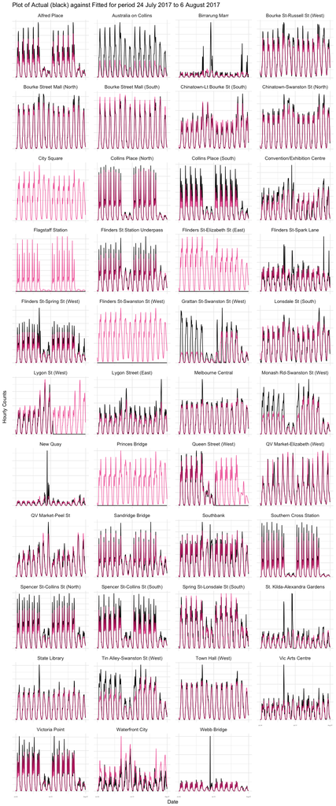

Looking at plots of actuals (black) against fitted of data from 24 July 2017 to 6 August 2017, we see that some sensors appear to be not operational. We see that there is a mix of very good fitting models and not so good ones. An example of of a reasonably good fitting model is the *Collins Place (North)* sensor location:

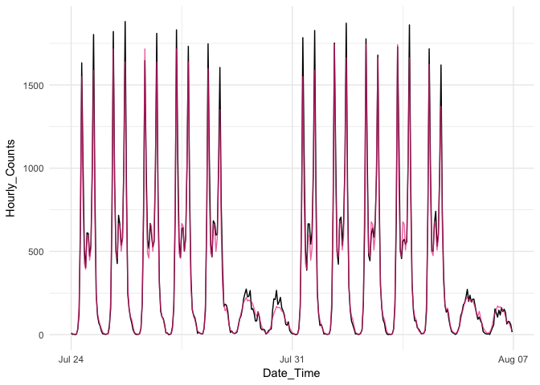

```r
ggplot(test_fitted %>%
         filter(Date > "2017-07-23",
                Sensor == "Collins Place (North)")) +
      geom_line(aes(x = Date_Time, y = Hourly_Counts)) +
      geom_line(aes(x = Date_Time, y = Fitted), colour = 'violetred2', alpha = 0.7) +
      theme_minimal()
```

```r
col_pl_test_rmse <- test_fitted %>% filter(Date > "2017-07-23", Sensor == "Collins Place (North)") %>%
               mutate(residsq = (Fitted - Hourly_Counts)^2) %>% .$residsq %>% mean() %>% sqrt()
```

Using RMSE (root mean square error) as a goodness of fit measure, we find that the RMSE of the prediction represented in the plot above is 65.6396. In comparison, the model predicted for the sensor located on *Grattan St-Swanston St (West)* fits very poorly:

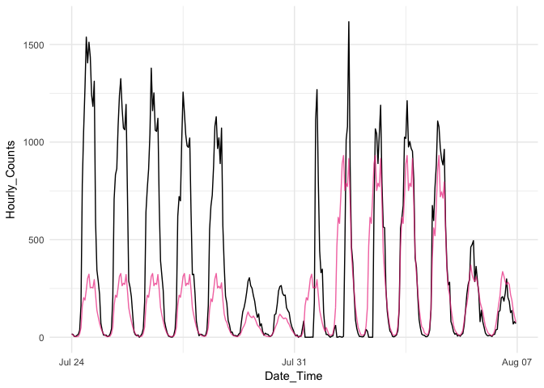

Here, the poor fit results in a RMSE of 362.8872 for the period between Jul 24 to Aug 6. It appears as though the additive effect of `Month` is exaggerated, where we see that predictions in July are significantly underestimated, compared to August predictions which have adequate fit. If we compare the RMSE between July predictions and August predictions, we find that the RMSE of the predictions of Aug 1 to Aug 6 is much lower than that of the predictions for Jul 24 to Jul 31 (216.4857 compared to 441.9308)

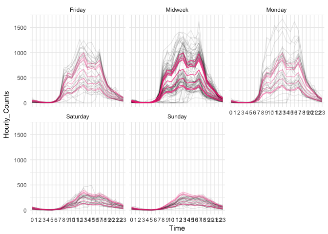

Looking at the counts for each day, we see that the variance during weekdays is quite large. This would suggest that the day of the week and time of the day do not explain a lot of the variance in the data.

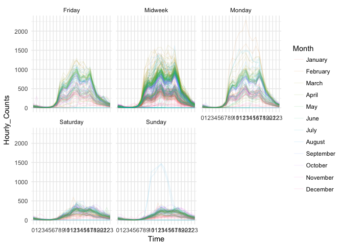

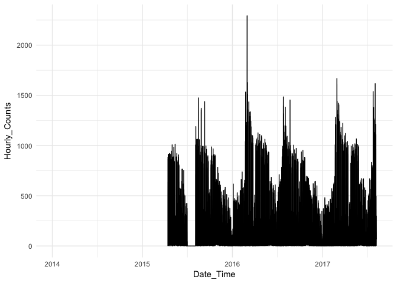

However, we see that the variance within a month is quite low comparatively. It is worth noting that the data available at this location is very poor.  
Plotting all available observations, we see we only have data starting from 2015-04-13.

Computing the RMSE for all of the test set (2017 data) for each sensor:

```r
test_df <- test_fitted %>% mutate(residsq = (Fitted - Hourly_Counts)^2) %>%
            split(.$Sensor_ID)
test_df_rmse <- data.frame(Sensor_ID = rep(0,43), RMSE = rep(0, 43))
  for (i in 1:43) {
      test_df_rmse$Sensor_ID[i] <- names(test_df)[i]
      test_df_rmse$RMSE[i] <- mean(test_df[[i]]$residsq) %>% sqrt()
  }

test_df_plot <- test_fitted %>% filter(Date > "2017-07-23") %>%
            mutate(residsq = (Fitted - Hourly_Counts)^2) %>%
            split(.$Sensor_ID)
test_df_rmse_plot <- data.frame(Sensor_ID = rep(0,43), RMSE = rep(0, 43))
  for (i in 1:43) {
      test_df_rmse_plot$Sensor_ID[i] <- names(test_df_plot)[i]
      test_df_rmse_plot$RMSE[i] <- mean(test_df_plot[[i]]$residsq) %>% sqrt()
  }
pander(arrange(test_df_rmse, by= RMSE))
```

| Sensor_ID | RMSE |
| --- | --- |
| QV Market-Peel St | 44.17 |
| Tin Alley-Swanston St (West) | 47.63 |
| Webb Bridge | 64.82 |
| Waterfront City | 67.84 |
| Lygon Street (East) | 86.3 |
| Victoria Point | 92.08 |
| Flinders St-Spark Lane | 93.46 |
| Flinders St-Spring St (West) | 101.3 |
| Lygon St (West) | 106 |
| Chinatown-Lt Bourke St (South) | 107.3 |
| Monash Rd-Swanston St (West) | 122.5 |
| Collins Place (North) | 123.3 |
| Queen Street (West) | 144.2 |
| Alfred Place | 145.3 |
| Spring St-Lonsdale St (South) | 148.4 |
| Grattan St-Swanston St (West) | 153.5 |
| Collins Place (South) | 165.3 |
| Bourke St-Russell St (West) | 178.6 |
| QV Market-Elizabeth (West) | 181.3 |
| Lonsdale St (South) | 182.3 |
| Spencer St-Collins St (South) | 205.3 |
| Chinatown-Swanston St (North) | 217.8 |
| Sandridge Bridge | 221.6 |
| Bourke Street Mall (South) | 228.6 |
| Convention/Exhibition Centre | 243.2 |
| New Quay | 270.9 |
| Southern Cross Station | 363.6 |
| State Library | 399.5 |
| St. Kilda-Alexandra Gardens | 428.9 |
| Australia on Collins | 460.2 |
| Melbourne Central | 505.2 |
| Flinders St Station Underpass | 528.3 |
| Bourke Street Mall (North) | 594.2 |
| Vic Arts Centre | 601 |
| Southbank | 603.7 |
| Spencer St-Collins St (North) | 677.4 |
| Princes Bridge | 730.5 |
| Birrarung Marr | 781 |
| Flagstaff Station | 980.7 |
| Town Hall (West) | 1672 |
| Flinders St-Swanston St (West) | 2722 |
| City Square | NA |
| Flinders St-Elizabeth St (East) | NA |